# Group Assignment 4 - Creative Gaming

Section 51

Gaurav Agrawal, Ajitesh Abhishek, Tarun Joshi

[output not shown]

### Read in the data:

```r
# use load("filename.Rdata") for .Rdata files
data = load("smobile_churn.Rdata")
smobile <- smobile %>% mutate(churn = ifelse(churn == "X1", 1, 0))
```

##Question 1: Step 1

```r
data.train <- smobile %>%
  filter(training==1)
```

```r
data.test <- smobile %>%
filter(training==0)
```

## Question 1

```r
fm <- formula(churn ~.  -customer)
logit.churn <- glm(fm, family=binomial(logit), data = data.train)

predictions_logit.churn <- predict(logit.churn,
                                   newdata = data.test,
                                   type = "response")
```

```
prediction from a rank-deficient fit may be misleading
```

| model | auc |
| --- | --- |
| data.test$churn_score_logit | 0.614 |

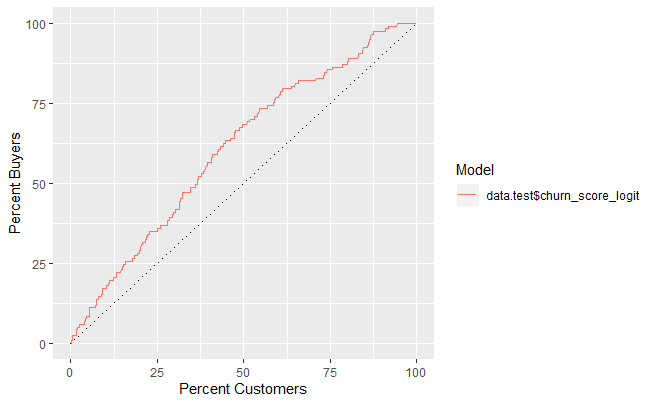

```r
data.test <- data.test %>%
  mutate(churn_score_logit = predictions_logit.churn)

gainsplot(data.test$churn_score_logit,label.var = data.test$churn)
```

```r
summary(logit.churn)
```

```
Call:
glm(formula = fm, family = binomial(logit), data = data.train)

Deviance Residuals:
    Min       1Q   Median       3Q      Max
-0.9621  -0.3140  -0.2634  -0.2158   3.1756

Coefficients: (1 not defined because of singularities)
              Estimate Std. Error z value Pr(>|z|)
(Intercept) -3.0790100  0.3927087  -7.840 4.49e-15 ***
revenue      0.0023081  0.0026485   0.871 0.383512
mou         -0.0005223  0.0002282  -2.289 0.022082 *
overage      0.0012991  0.0008707   1.492 0.135689
roam         0.0011300  0.0091256   0.124 0.901454
changem     -0.0001456  0.0003150  -0.462 0.644007
changer     -0.0011700  0.0020578  -0.569 0.569664
dropvce      0.0003786  0.0088781   0.043 0.965982
blckvce      0.0157017  0.0039198   4.006 6.18e-05 ***
unansvce     0.0013042  0.0021420   0.609 0.542628
custcare    -0.0059974  0.0168837  -0.355 0.722428
threeway    -0.0233032  0.0328647  -0.709 0.478284
months      -0.0181096  0.0107572  -1.683 0.092281 .
uniqsubs     0.1638001  0.0636055   2.575 0.010017 *
phones       0.0311120  0.0708582   0.439 0.660607
eqpdays      0.0013142  0.0003807   3.452 0.000557 ***
age         -0.0162599  0.0068316  -2.380 0.017308 *
children1   -0.0434708  0.1643164  -0.265 0.791352
creditaa1   -0.5547280  0.2264624  -2.450 0.014304 *
refurb1      0.0265338  0.1917298   0.138 0.889931
occprof1     0.2074751  0.1891593   1.097 0.272717
occcler1    -0.0641170  0.5219908  -0.123 0.902240
occcrft1     0.5967373  0.3194304   1.868 0.061744 .
occstud1     0.2242857  0.7366422   0.304 0.760770
occhmkr1     0.8009078  0.7505756   1.067 0.285946
occret1      0.1974465  0.6198244   0.319 0.750066
occself1     0.3147290  0.4757480   0.662 0.508262
travel1     -0.1672166  0.3064518  -0.546 0.585304
retcalls     0.4969203  0.2733701   1.818 0.069101 .
refer       -0.5650638  0.3783102  -1.494 0.135267
incmiss1     0.1611407  0.3196411   0.504 0.614170
income      -0.0122394  0.0354409  -0.345 0.729833
mcycle1     -0.1849379  0.5972747  -0.310 0.756838
agemiss1    -0.4348835  0.3683478  -1.181 0.237749
training            NA         NA      NA       NA
---
Signif. codes:  0 ‘***’ 0.001 ‘**’ 0.01 ‘*’ 0.05 ‘.’ 0.1 ‘ ’ 1

(Dispersion parameter for binomial family taken to be 1)

    Null deviance: 2325.7  on 6999  degrees of freedom
Residual deviance: 2245.4  on 6966  degrees of freedom
AIC: 2313.4

Number of Fisher Scoring iterations: 6
```

```r
fm <- formula(churn ~. -customer)

random.churn <- ranger(fm, data=data.train, probability = TRUE)

predictions_rf.churn <- predict(random.churn, data = data.test, type="response")[[1]][,2]

data.test <- data.test %>%
  mutate(churn_score_rf = predictions_rf.churn)

gainsplot(data.test$churn_score_rf,label.var = data.test$churn)
```

| model | auc |
| --- | --- |
| data.test$churn_score_rf | 0.578 |

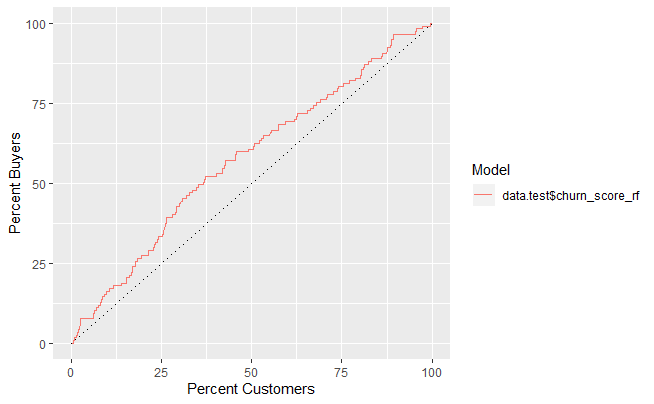

```r
NA
```

## Question 2

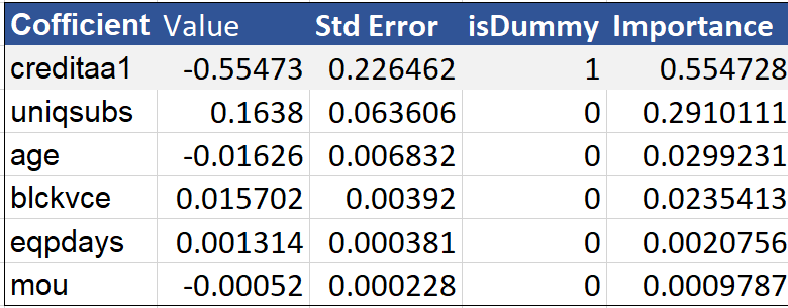

Variable Importance

## Question 3

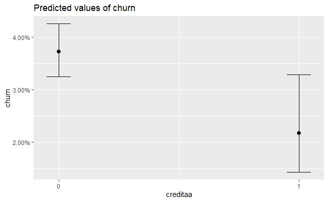

```r
plot_model(logit.churn, type="eff", terms = c("creditaa"))
```

Customers with high credit rating have lower churn. Hence, the firm should take extra care of cutsomers who don’t high rating - offer discounts, monitor satisfaction, priority queue for customer complaint handling etc.

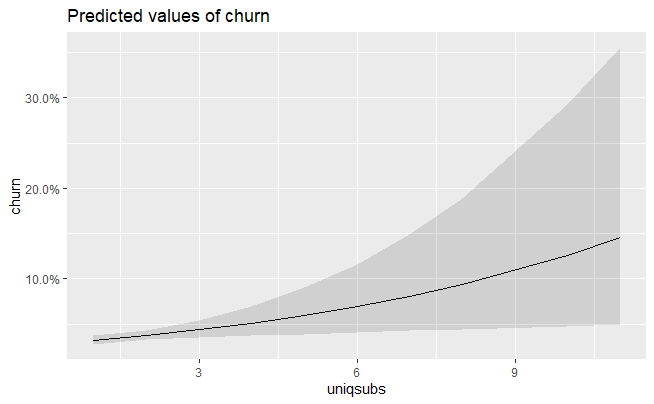

```r
plot_model(logit.churn, type="eff", terms = c("uniqsubs"))
```

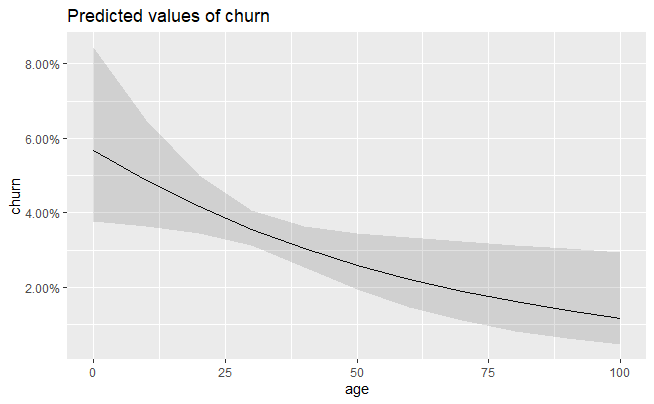

```r
plot_model(logit.churn, type="eff", terms = c("age"))
```

Launch “For Senior Citizen” plan offering expediated customer service and enrol people above age 50 years.

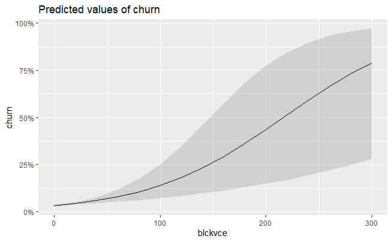

```r
plot_model(logit.churn, type="eff", terms = c("blckvce"))
```

Consumers usually block the spam calls. Hence, work with developer on spam detection model. Lower spam could reduce the churn for the firm.

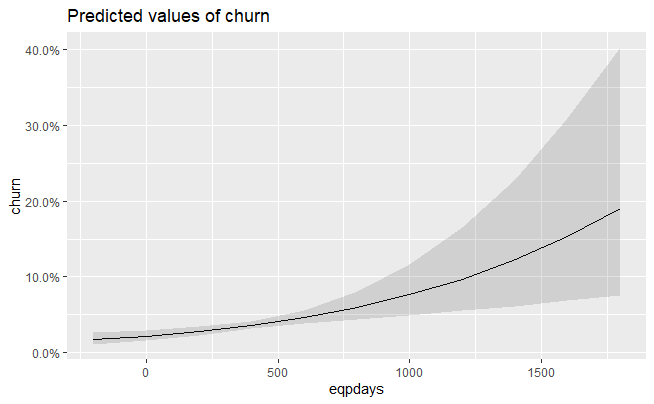

```r
plot_model(logit.churn, type="eff", terms = c("eqpdays"))
```

Tieup with equipment provider to help customer switch to new devices. Offer attractive plan to users with new devices.

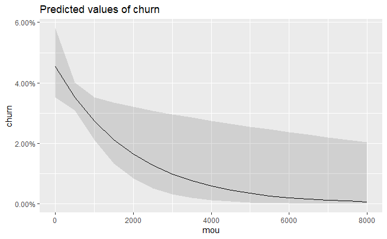

```r
plot_model(logit.churn, type="eff", terms = c("mou"))
```

Build tariff plan offering high minutes to each tier. Also, reduce the call rates or added incentives such as extra 4G data to customers with high monthly minutes of use.

## Question 4

```r
rollout <- rollout %>%
  mutate(training = 1)

predictions_logit.churn.rollout <- predict(logit.churn, newdata = rollout, type = "response")
```

```
prediction from a rank-deficient fit may be misleading
```

```r
rollout <- rollout %>%
  mutate(churn_score_logit = predictions_logit.churn.rollout)
```

```r
rollout_new <- rollout %>%
    mutate(age=age+10)

churn_age_pred <- predict(logit.churn, newdata = rollout_new, type = "response")
```

```
prediction from a rank-deficient fit may be misleading
```

```r
rollout_new  <- rollout_new  %>%
  mutate(churn_age_pred = churn_age_pred)

orig_churn <- rollout_new %>%
  summarise(mean(churn_score_logit)*100)

new_churn_age <- rollout_new %>%
  summarise(mean(churn_age_pred)*100)

change_per_age <- new_churn_age - orig_churn

print(orig_churn)
```

| mean(churn_score_logit) * 100 |
| --- |
| 3.934331 |

```r
print(new_churn_age)
```

| mean(churn_age_pred) * 100 |
| --- |
| 3.37002 |

```r
print(change_per_age)
```

| mean(churn_age_pred) * 100 |
| --- |
| -0.5643104 |

```r
rollout_new <- rollout %>%
    mutate(creditaa = "1")

churn_credit_pred <- predict(logit.churn, newdata = rollout_new, type = "response")
```

```
prediction from a rank-deficient fit may be misleading
```

```r
rollout_new  <- rollout_new  %>%
  mutate(churn_credit_pred = churn_credit_pred)

orig_churn <- rollout_new %>%
  summarise(mean(churn_score_logit)*100)

new_churn_credit <- rollout_new %>%
  summarise(mean(churn_credit_pred)*100)

change_per_credit <- new_churn_credit - orig_churn

print(orig_churn)
```

| mean(churn_score_logit) * 100 |
| --- |
| 3.934331 |

```r
print(new_churn_credit)
```

| mean(churn_credit_pred) * 100 |
| --- |
| 2.45198 |

```r
print(change_per_credit)
```

| mean(churn_credit_pred) * 100 |
| --- |
| -1.48235 |

```r
rollout_new <- rollout %>%
    mutate(blckvce = blckvce*0.5)

churn_blckvce_pred <- predict(logit.churn, newdata = rollout_new, type = "response")
```

```
prediction from a rank-deficient fit may be misleading
```

```r
rollout_new  <- rollout_new  %>%
  mutate(churn_blckvce_pred = churn_blckvce_pred)

orig_churn <- rollout_new %>%
  summarise(mean(churn_score_logit)*100)

new_churn_blckvce <- rollout_new %>%
  summarise(mean(churn_blckvce_pred)*100)

change_per_blckvce <- new_churn_blckvce - orig_churn

print(orig_churn)
```

| mean(churn_score_logit) * 100 |
| --- |
| 3.934331 |

```r
print(new_churn_blckvce)
```

| mean(churn_blckvce_pred) * 100 |
| --- |
| 3.78799 |

```r
print(change_per_blckvce)
```

| mean(churn_blckvce_pred) * 100 |
| --- |
| -0.146341 |

```r
rollout_new <- rollout %>%
    mutate(uniqsubs = uniqsubs-1)

churn_uniqsubs_pred <- predict(logit.churn, newdata = rollout_new, type = "response")
```

```
prediction from a rank-deficient fit may be misleading
```

```r
rollout_new  <- rollout_new  %>%
  mutate(churn_uniqsubs_pred = churn_uniqsubs_pred)

orig_churn <- rollout_new %>%
  summarise(mean(churn_score_logit)*100)

new_churn_uniqsubs <- rollout_new %>%
  summarise(mean(churn_uniqsubs_pred)*100)

change_per_uniqsubs <- new_churn_uniqsubs - orig_churn

print(orig_churn)
```

| mean(churn_score_logit) * 100 |
| --- |
| 3.934331 |

```r
print(new_churn_uniqsubs)
```

| mean(churn_uniqsubs_pred) * 100 |
| --- |
| 3.366153 |

```r
print(change_per_uniqsubs)
```

| mean(churn_uniqsubs_pred) * 100 |
| --- |
| -0.5681776 |

```r
rollout_new <- rollout %>%
    mutate(eqpdays = eqpdays*0.5)

churn_eqpdays_pred <- predict(logit.churn, newdata = rollout_new, type = "response")
```

```
prediction from a rank-deficient fit may be misleading
```

```r
rollout_new  <- rollout_new  %>%
  mutate(churn_eqpdays_pred = churn_eqpdays_pred)

orig_churn <- rollout_new %>%
  summarise(mean(churn_score_logit)*100)

new_churn_eqpdays <- rollout_new %>%
  summarise(mean(churn_eqpdays_pred)*100)

change_per_eqpdays <- new_churn_eqpdays - orig_churn

print(orig_churn)
```

| mean(churn_score_logit) * 100 |
| --- |
| 3.934331 |

```r
print(new_churn_eqpdays)
```

| mean(churn_eqpdays_pred) * 100 |
| --- |
| 3.053326 |

```r
print(change_per_eqpdays)
```

| mean(churn_eqpdays_pred) * 100 |
| --- |
| -0.8810047 |

Impact on churn by just changing for a specific segment

```r
rollout %>%
  summarise(mean(mou))
```

| mean(mou) |
| --- |
| 539.6545 |

```r
NA
```

```r
rollout_mou_new <- rollout %>%
  arrange(-mou)%>%
  slice(1:800)%>%
  mutate(mou=mou+180)

churn_mou <- predict(logit.churn, newdata = rollout_mou_new, type = "response")
```

```
prediction from a rank-deficient fit may be misleading
```

```r
rollout_mou_new  <- rollout_mou_new  %>%
  mutate(churn_mou = churn_mou)

orig_churn_mou <- rollout_mou_new %>%
  summarise(mean(churn_score_logit)*100)

new_churn_mou <- rollout_mou_new %>%
  summarise(mean(churn_mou)*100)

change_mou <- new_churn_mou - orig_churn_mou

print(orig_churn_mou)
```

| mean(churn_score_logit) * 100 |
| --- |
| 3.33574 |

```r
print(new_churn_mou)
```

| mean(churn_mou) * 100 |
| --- |
| 3.055615 |

```r
print(change_mou)
```

| mean(churn_mou) * 100 |
| --- |
| -0.280125 |

Changing credit rating

```r
rollout_creditaa_new <- rollout %>%
  filter(creditaa==0)%>%
  mutate(creditaa="1")

churn_creditaa <- predict(logit.churn, newdata = rollout_creditaa_new, type = "response")
```

```
prediction from a rank-deficient fit may be misleading
```

```r
rollout_creditaa_new  <- rollout_creditaa_new  %>%
  mutate(churn_creditaa = churn_creditaa)

orig_churn_creditaa <- rollout_creditaa_new %>%
  summarise(mean(churn_score_logit)*100)

new_churn_creditaa <- rollout_creditaa_new %>%
  summarise(mean(churn_creditaa)*100)

change_creditaa <- new_churn_creditaa - orig_churn_creditaa

print(orig_churn_creditaa)
```

| mean(churn_score_logit) * 100 |
| --- |
| 4.176134 |

```r
print(new_churn_creditaa)
```

| mean(churn_creditaa) * 100 |
| --- |
| 2.453641 |

```r
print(change_creditaa)
```

| mean(churn_creditaa) * 100 |
| --- |
| -1.722493 |

```r
avg_monthly_revenue <- rollout%>%
  summarise(mean(revenue))

avg_monthly_revenue
```

| mean(revenue) |
| --- |
| 58.85216 |

Change Unique Subscribers:

```r
rollout %>%
  tabyl(uniqsubs)
```

```
 uniqsubs    n      percent
        1 5173 0.6456565152
        2 2054 0.2563654518
        3  507 0.0632800799
        4  180 0.0224663005
        5   61 0.0076135796
        6   27 0.0033699451
        7    4 0.0004992511
        8    3 0.0003744383
        9    1 0.0001248128
       10    1 0.0001248128
       11    1 0.0001248128
```

```r
rollout_uniqsubs_new <- rollout %>%
  filter(uniqsubs==2)%>%
  mutate(uniqsubs=1)

churn_uniqsubs <- predict(logit.churn, newdata = rollout_uniqsubs_new, type = "response")
```

```
prediction from a rank-deficient fit may be misleading
```

```r
rollout_uniqsubs_new  <- rollout_uniqsubs_new  %>%
  mutate(churn_uniqsubs = churn_uniqsubs)

orig_churn_uniqsubs <- rollout_uniqsubs_new %>%
  summarise(mean(churn_score_logit)*100)

new_churn_uniqsubs <- rollout_uniqsubs_new %>%
  summarise(mean(churn_uniqsubs)*100)

change_uniqsubs <- new_churn_uniqsubs - orig_churn_uniqsubs

print(orig_churn_uniqsubs)
```

| mean(churn_score_logit) * 100 |
| --- |
| 4.371285 |

```r
print(new_churn_uniqsubs)
```

| mean(churn_uniqsubs) * 100 |
| --- |
| 3.742702 |

```r
print(change_uniqsubs)
```

| mean(churn_uniqsubs) * 100 |
| --- |
| -0.6285828 |

```r
rollout_blckvce_new <- rollout %>%
  arrange(blckvce)%>%
  slice(1:800)%>%
  mutate(blckvce=blckvce*0.5)

churn_blckvce <- predict(logit.churn, newdata = rollout_mou_new, type = "response")
```

```
prediction from a rank-deficient fit may be misleading
```

```r
rollout_blckvce_new  <- rollout_blckvce_new  %>%
  mutate(churn_blckvce = churn_blckvce)

orig_churn_blckvce <- rollout_blckvce_new %>%
  summarise(mean(churn_score_logit)*100)

new_churn_blckvce <- rollout_blckvce_new %>%
  summarise(mean(churn_blckvce)*100)

change_blckvce <- new_churn_blckvce - orig_churn_blckvce

print(orig_churn_blckvce)
```

| mean(churn_score_logit) * 100 |
| --- |
| 4.045178 |

```r
print(new_churn_blckvce)
```

| mean(churn_blckvce) * 100 |
| --- |
| 3.055615 |

```r
print(change_blckvce)
```

| mean(churn_blckvce) * 100 |
| --- |
| -0.9895624 |

```r
rollout %>%
  arrange(-eqpdays)%>%
  slice(1:800)%>%
  summarise(mean(eqpdays))
```

| mean(eqpdays) |
| --- |
| 900.9438 |

```r
rollout_eqpdays_new <- rollout %>%
  arrange(-eqpdays)%>%
  slice(1:800)%>%
  mutate(eqpdays=2*365)

churn_eqpdays <- predict(logit.churn, newdata = rollout_eqpdays_new, type = "response")
```

```
prediction from a rank-deficient fit may be misleading
```

```r
rollout_eqpdays_new  <- rollout_eqpdays_new  %>%
  mutate(churn_eqpdays = churn_eqpdays)

orig_churn_eqpdays <- rollout_eqpdays_new %>%
  summarise(mean(churn_score_logit)*100)

new_churn_eqpdays <- rollout_eqpdays_new %>%
  summarise(mean(churn_eqpdays)*100)

change_eqpdays <- new_churn_eqpdays - orig_churn_eqpdays

print(orig_churn_eqpdays)
```

| mean(churn_score_logit) * 100 |
| --- |
| 5.806141 |

```r
print(new_churn_eqpdays)
```

| mean(churn_eqpdays) * 100 |
| --- |
| 4.707415 |

```r
print(change_eqpdays)
```

| mean(churn_eqpdays) * 100 |
| --- |
| -1.098725 |